# Ezra Cohen lab 5

```r
library(RCurl)
library(jsonlite)
station_link <- 'https://gbfs.citibikenyc.com/gbfs/en/station_status.json'
apiOutput <- getURL(station_link)
apiData <- fromJSON(apiOutput)
stationStatus <- apiData$data$stations
cols <- c('num_bikes_disabled','num_docks_disabled', 'station_id', 'num_ebikes_available', 'num_bikes_available', 'num_docks_available')
stationStatus = stationStatus[,cols]
```

task 1

a data set showing the number of stations and bikes in those station

task 2

library(RCurl) library(jsonlite) these allow use of necessary packages station_link <- 'https://gbfs.citibikenyc.com/gbfs/en/station_status.json' makes a varriable that is the link apiOutput <- getURL(station_link)  
gets information/results from that url and stores it in varriable apiData <- fromJSON(apiOutput) converts the results to a dataframe R stationStatus <- apiData$data$stations sets stationStatus to the data in stations cols <- c('num_bikes_disabled','num_docks_disabled', 'station_id', 'num_ebikes_available', 'num_bikes_available', 'num_docks_available') makes a vector called cols that has the names of some of the collumns in stations stationStatus = stationStatus[,cols] sets stationStatus to the collumns that were made in cols

task 3

```r
str(apiOutput)
str(apiData)
```

```
 chr "{\"data\":{\"stations\":[{\"is_installed\":1,\"num_bikes_disabled\":3,\"num_bikes_available\":3,\"eightd_has_av"| __truncated__
List of 3
 $ data        :List of 1
  ..$ stations:'data.frame':	1571 obs. of  15 variables:
  .. ..$ is_installed                  : int [1:1571] 1 1 1 1 1 1 1 1 1 1 ...
  .. ..$ num_bikes_disabled            : int [1:1571] 3 1 2 1 1 5 1 0 3 5 ...
  .. ..$ num_bikes_available           : int [1:1571] 3 25 19 51 12 45 4 2 51 42 ...
  .. ..$ eightd_has_available_keys     : logi [1:1571] FALSE FALSE FALSE FALSE FALSE FALSE ...
  .. ..$ station_id                    : chr [1:1571] "72" "79" "82" "83" ...
  .. ..$ station_status                : chr [1:1571] "active" "active" "active" "active" ...
  .. ..$ is_renting                    : int [1:1571] 1 1 1 1 1 1 1 1 1 1 ...
  .. ..$ legacy_id                     : chr [1:1571] "72" "79" "82" "83" ...
  .. ..$ num_ebikes_available          : int [1:1571] 0 0 0 1 0 0 0 0 1 0 ...
  .. ..$ last_reported                 : int [1:1571] 1627408890 1627408920 1627407794 1627408968 1627408978 1627408632 1627408697 1627408651 1627408690 1627408130 ...
  .. ..$ num_docks_disabled            : int [1:1571] 0 0 0 0 0 0 0 0 0 0 ...
  .. ..$ is_returning                  : int [1:1571] 1 1 1 1 1 1 1 1 1 1 ...
  .. ..$ num_docks_available           : int [1:1571] 49 7 6 10 37 3 14 29 2 3 ...
  .. ..$ valet                         :'data.frame':	1571 obs. of  7 variables:
  .. .. ..$ off_dock_capacity : int [1:1571] NA NA NA NA NA NA NA NA NA NA ...
  .. .. ..$ region            : chr [1:1571] NA NA NA NA ...
  .. .. ..$ station_id        : chr [1:1571] NA NA NA NA ...
  .. .. ..$ dock_blocked_count: int [1:1571] NA NA NA NA NA NA NA NA NA NA ...
  .. .. ..$ off_dock_count    : int [1:1571] NA NA NA NA NA NA NA NA NA NA ...
  .. .. ..$ active            : logi [1:1571] NA NA NA NA NA NA ...
  .. .. ..$ valet_revision    : int [1:1571] NA NA NA NA NA NA NA NA NA NA ...
  .. ..$ eightd_active_station_services:List of 1571
  .. .. ..$ : NULL
  .. .. ..$ : NULL
  .. .. ..$ : NULL
  .. .. ..$ : NULL
  .. .. ..$ : NULL
  .. .. ..$ : NULL
  .. .. ..$ : NULL
  .. .. ..$ : NULL
  .. .. ..$ : NULL
  .. .. ..$ : NULL
  .. .. ..$ : NULL
  .. .. ..$ : NULL
  .. .. ..$ : NULL
  .. .. ..$ : NULL
```

[output cut: 75 more lines]

```
  .. .. ..$ : NULL
  .. .. ..$ : NULL
  .. .. ..$ : NULL
  .. .. ..$ : NULL
  .. .. ..$ : NULL
  .. .. ..$ : NULL
  .. .. ..$ : NULL
  .. .. ..$ : NULL
  .. .. ..$ : NULL
  .. .. ..$ : NULL
  .. .. ..$ : NULL
  .. .. ..$ : NULL
  .. .. .. [list output truncated]
 $ last_updated: int 1627409005
 $ ttl         : int 5
```

task 4

```r
prettify(apiOutput)
```

```
{
    "data": {
        "stations": [
            {
                "is_installed": 1,
                "num_bikes_disabled": 3,
                "num_bikes_available": 3,
                "eightd_has_available_keys": false,
                "station_id": "72",
                "station_status": "active",
                "is_renting": 1,
                "legacy_id": "72",
                "num_ebikes_available": 0,
                "last_reported": 1627408890,
                "num_docks_disabled": 0,
                "is_returning": 1,
                "num_docks_available": 49
            },
            {
                "is_installed": 1,
                "num_bikes_disabled": 1,
                "num_bikes_available": 25,
                "eightd_has_available_keys": false,
                "station_id": "79",
                "station_status": "active",
                "is_renting": 1,
                "legacy_id": "79",
                "num_ebikes_available": 0,
                "last_reported": 1627408920,
                "num_docks_disabled": 0,
                "is_returning": 1,
                "num_docks_available": 7
            },
            {
                "is_installed": 1,
                "num_bikes_disabled": 2,
                "num_bikes_available": 19,
                "eightd_has_available_keys": false,
                "station_id": "82",
                "station_status": "active",
```

[output cut: 23658 more lines]

```
                "station_id": "4641",
                "station_status": "active",
                "is_renting": 1,
                "legacy_id": "4641",
                "num_ebikes_available": 1,
                "last_reported": 1627408957,
                "num_docks_disabled": 0,
                "is_returning": 1,
                "num_docks_available": 19
            }
        ]
    },
    "last_updated": 1627409005,
    "ttl": 5
}
```

gives all information about each row one row at a time

task 5

```r
str(stationStatus)
```

```
'data.frame':	1571 obs. of  6 variables:
 $ num_bikes_disabled  : int  3 1 2 1 1 5 1 0 3 5 ...
 $ num_docks_disabled  : int  0 0 0 0 0 0 0 0 0 0 ...
 $ station_id          : chr  "72" "79" "82" "83" ...
 $ num_ebikes_available: int  0 0 0 1 0 0 0 0 1 0 ...
 $ num_bikes_available : int  3 25 19 51 12 45 4 2 51 42 ...
 $ num_docks_available : int  49 7 6 10 37 3 14 29 2 3 ...
```

it's a dataframe and it gives information on the number of bikes disabled, number of docks disabled, station id, number of ebikes available, number of bikes available, and number of docks available for each station

task 6

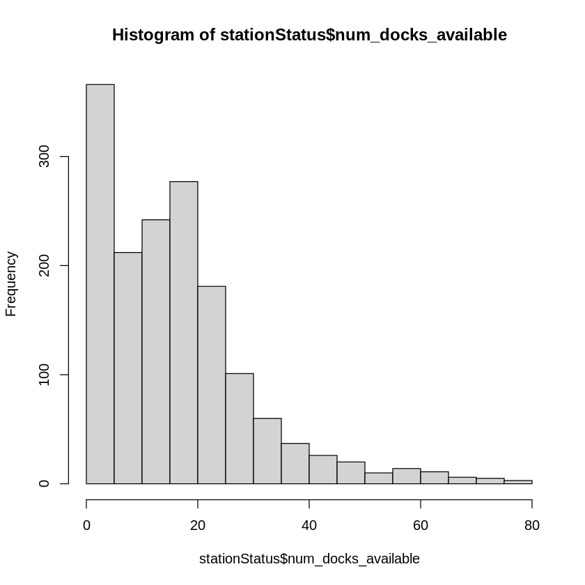

```r
hist(stationStatus$num_docks_available)
```

task 7

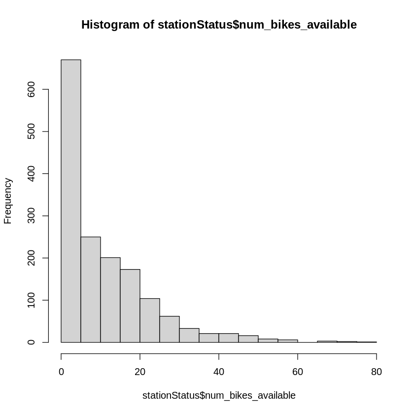

```r
hist(stationStatus$num_bikes_available)
```

task 8

```r
ebikestation<-stationStatus$num_ebikes_available>=1
ebikestations<-which(ebikestation==TRUE)
length(ebikestations)
```

455

task 9

```r
Ebikestations <- data.frame(stationStatus[c(which(ebikestation==TRUE)),])
Ebikestations
```

A data.frame: 455 × 6

|  | num_bikes_disabled <int> | num_docks_disabled <int> | station_id <chr> | num_ebikes_available <int> | num_bikes_available <int> | num_docks_available <int> |
| --- | --- | --- | --- | --- | --- | --- |
| 4 | 1 | 0 | 83 | 1 | 51 | 10 |
| 9 | 3 | 0 | 128 | 1 | 51 | 2 |
| 18 | 3 | 0 | 161 | 1 | 21 | 11 |
| 23 | 2 | 0 | 212 | 1 | 7 | 51 |
| 26 | 3 | 0 | 223 | 2 | 15 | 15 |
| 32 | 1 | 0 | 238 | 1 | 1 | 29 |
| 33 | 4 | 0 | 239 | 1 | 27 | 0 |
| 39 | 2 | 0 | 248 | 1 | 16 | 73 |
| 42 | 2 | 0 | 251 | 1 | 19 | 6 |
| 43 | 2 | 0 | 252 | 1 | 10 | 21 |
| 48 | 4 | 0 | 260 | 1 | 25 | 4 |
| 53 | 1 | 0 | 266 | 1 | 6 | 23 |
| 55 | 2 | 0 | 268 | 1 | 21 | 4 |
| 56 | 1 | 0 | 270 | 1 | 14 | 13 |
| 58 | 0 | 0 | 275 | 1 | 4 | 15 |
| 61 | 8 | 61 | 281 | 1 | 12 | 0 |
| 64 | 2 | 0 | 285 | 1 | 25 | 51 |
| 68 | 1 | 0 | 295 | 1 | 17 | 6 |
| 73 | 2 | 0 | 303 | 1 | 57 | 8 |
| 74 | 8 | 26 | 304 | 2 | 17 | 0 |
| 75 | 2 | 0 | 305 | 2 | 24 | 7 |
| 79 | 8 | 0 | 310 | 1 | 58 | 0 |
| 81 | 1 | 0 | 312 | 5 | 10 | 22 |
| 82 | 2 | 0 | 313 | 1 | 51 | 2 |
| 83 | 6 | 0 | 315 | 1 | 23 | 0 |
| 85 | 0 | 0 | 317 | 1 | 4 | 63 |
| 86 | 8 | 0 | 319 | 2 | 25 | 0 |
| 93 | 3 | 0 | 327 | 1 | 26 | 10 |
| 95 | 2 | 0 | 330 | 16 | 40 | 0 |
| 98 | 5 | 0 | 334 | 2 | 10 | 29 |
| ⋮ | ⋮ | ⋮ | ⋮ | ⋮ | ⋮ | ⋮ |
| 1482 | 3 | 0 | 4541 | 1 | 5 | 11 |
| 1483 | 0 | 0 | 4542 | 3 | 3 | 17 |
| 1486 | 1 | 0 | 4545 | 2 | 4 | 26 |
| 1490 | 1 | 0 | 4551 | 1 | 1 | 18 |
| 1493 | 1 | 0 | 4555 | 1 | 3 | 21 |
| 1495 | 3 | 0 | 4557 | 2 | 3 | 18 |
| 1498 | 0 | 0 | 4561 | 1 | 10 | 17 |
| 1501 | 0 | 0 | 4564 | 3 | 4 | 17 |
| 1502 | 0 | 0 | 4565 | 1 | 3 | 21 |
| 1504 | 2 | 0 | 4567 | 1 | 1 | 17 |
| 1506 | 0 | 0 | 4569 | 1 | 1 | 18 |
| 1511 | 1 | 0 | 4574 | 2 | 9 | 13 |
| 1516 | 1 | 0 | 4579 | 1 | 2 | 23 |
| 1519 | 2 | 0 | 4582 | 2 | 5 | 16 |
| 1520 | 4 | 0 | 4583 | 2 | 3 | 30 |
| 1522 | 2 | 0 | 4585 | 1 | 1 | 18 |
| 1527 | 2 | 0 | 4593 | 1 | 45 | 0 |
| 1528 | 2 | 0 | 4594 | 1 | 45 | 0 |
| 1532 | 2 | 0 | 4599 | 1 | 1 | 17 |
| 1534 | 2 | 0 | 4601 | 4 | 17 | 2 |
| 1538 | 3 | 0 | 4605 | 1 | 20 | 12 |
| 1539 | 3 | 0 | 4606 | 1 | 9 | 7 |
| 1543 | 1 | 0 | 4610 | 1 | 2 | 16 |
| 1546 | 1 | 0 | 4613 | 3 | 3 | 19 |
| 1547 | 0 | 0 | 4614 | 2 | 2 | 19 |
| 1551 | 4 | 0 | 4619 | 1 | 8 | 7 |
| 1561 | 4 | 0 | 4630 | 15 | 15 | 0 |
| 1566 | 0 | 0 | 4636 | 1 | 1 | 20 |
| 1567 | 1 | 0 | 4637 | 1 | 7 | 15 |
| 1571 | 8 | 0 | 4641 | 1 | 19 | 19 |

task 10

```r
mean(Ebikestations$num_docks_available)
```

16.2571428571429

task 11

```r
mean(stationStatus$num_docks_available)
```

16.462126034373

the means are increadibly close having a differance about .2

task 12

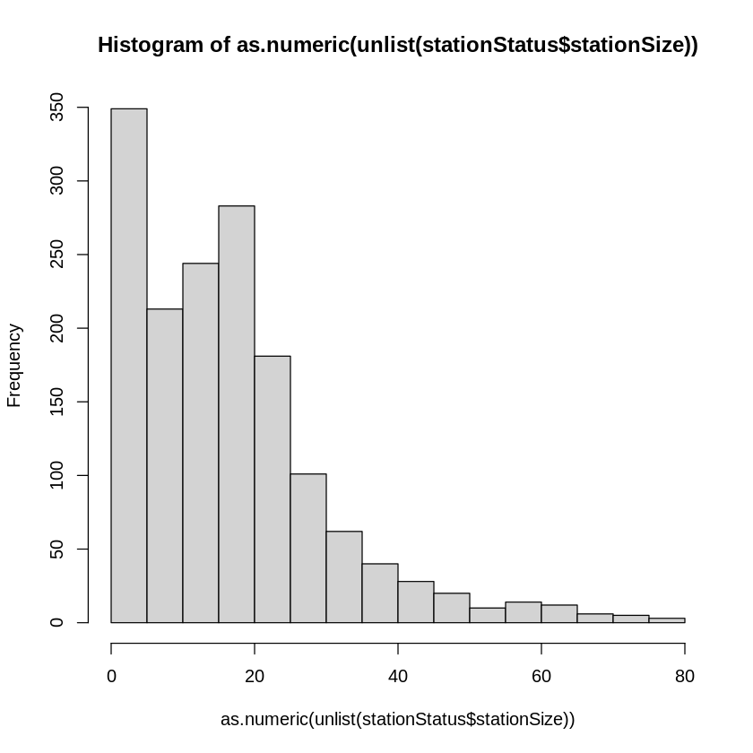

```r
stationStatus$stationSize <- data.frame(c(stationStatus$num_docks_available+stationStatus$num_docks_disabled))
hist(as.numeric(unlist(stationStatus$stationSize)))
#as.numeric and unlist were just put there in response to errors I got, the distribution is an inverted j shape
```

task 13

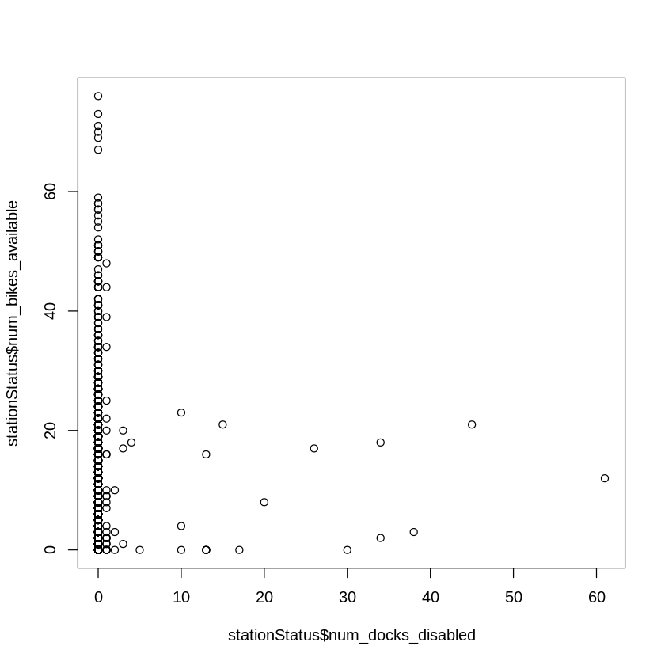

```r
plot(stationStatus$num_docks_disabled,stationStatus$num_bikes_available)
```